# importing the dataset and setting environment

```python
# This Python 3 environment comes with many helpful analytics libraries installed
# It is defined by the kaggle/python Docker image: https://github.com/kaggle/docker-python
# For example, here's several helpful packages to load

import numpy as np # linear algebra
import pandas as pd # data processing, CSV file I/O (e.g. pd.read_csv)

# Input data files are available in the read-only "../input/" directory
# For example, running this (by clicking run or pressing Shift+Enter) will list all files under the input directory

import os
for dirname, _, filenames in os.walk('/kaggle/input'):
    for filename in filenames:
        print(os.path.join(dirname, filename))

# You can write up to 20GB to the current directory (/kaggle/working/) that gets preserved as output when you create a version using "Save & Run All"
# You can also write temporary files to /kaggle/temp/, but they won't be saved outside of the current session
```

```
/kaggle/input/emnist/emnist-letters-mapping.txt
/kaggle/input/emnist/emnist-letters-test.csv
/kaggle/input/emnist/emnist-mnist-mapping.txt
/kaggle/input/emnist/emnist-digits-train.csv
/kaggle/input/emnist/emnist-bymerge-mapping.txt
/kaggle/input/emnist/emnist-balanced-train.csv
/kaggle/input/emnist/emnist-digits-test.csv
/kaggle/input/emnist/emnist-balanced-test.csv
/kaggle/input/emnist/emnist-mnist-test.csv
/kaggle/input/emnist/emnist-letters-train.csv
/kaggle/input/emnist/emnist-byclass-train.csv
/kaggle/input/emnist/emnist-bymerge-test.csv
/kaggle/input/emnist/emnist-balanced-mapping.txt
/kaggle/input/emnist/emnist-mnist-train.csv
/kaggle/input/emnist/emnist-digits-mapping.txt
/kaggle/input/emnist/emnist-bymerge-train.csv
/kaggle/input/emnist/emnist-byclass-test.csv
/kaggle/input/emnist/emnist-byclass-mapping.txt
/kaggle/input/emnist/emnist_source_files/emnist-digits-test-labels-idx1-ubyte
/kaggle/input/emnist/emnist_source_files/emnist-bymerge-train-labels-idx1-ubyte
/kaggle/input/emnist/emnist_source_files/emnist-letters-test-labels-idx1-ubyte
/kaggle/input/emnist/emnist_source_files/emnist-byclass-train-images-idx3-ubyte
/kaggle/input/emnist/emnist_source_files/emnist-byclass-test-images-idx3-ubyte
/kaggle/input/emnist/emnist_source_files/emnist-mnist-train-images-idx3-ubyte
/kaggle/input/emnist/emnist_source_files/emnist-digits-train-labels-idx1-ubyte
/kaggle/input/emnist/emnist_source_files/emnist-bymerge-test-images-idx3-ubyte
/kaggle/input/emnist/emnist_source_files/emnist-bymerge-test-labels-idx1-ubyte
/kaggle/input/emnist/emnist_source_files/emnist-mnist-test-labels-idx1-ubyte
/kaggle/input/emnist/emnist_source_files/emnist-balanced-test-labels-idx1-ubyte
/kaggle/input/emnist/emnist_source_files/emnist-balanced-test-images-idx3-ubyte
/kaggle/input/emnist/emnist_source_files/emnist-mnist-test-images-idx3-ubyte
/kaggle/input/emnist/emnist_source_files/emnist-bymerge-train-images-idx3-ubyte
/kaggle/input/emnist/emnist_source_files/emnist-letters-train-labels-idx1-ubyte
/kaggle/input/emnist/emnist_source_files/emnist-digits-train-images-idx3-ubyte
/kaggle/input/emnist/emnist_source_files/emnist-byclass-train-labels-idx1-ubyte
/kaggle/input/emnist/emnist_source_files/emnist-balanced-train-images-idx3-ubyte
/kaggle/input/emnist/emnist_source_files/emnist-balanced-train-labels-idx1-ubyte
/kaggle/input/emnist/emnist_source_files/emnist-letters-test-images-idx3-ubyte
/kaggle/input/emnist/emnist_source_files/emnist-byclass-test-labels-idx1-ubyte
/kaggle/input/emnist/emnist_source_files/emnist-letters-train-images-idx3-ubyte
/kaggle/input/emnist/emnist_source_files/emnist-mnist-train-labels-idx1-ubyte
/kaggle/input/emnist/emnist_source_files/emnist-digits-test-images-idx3-ubyte
/kaggle/input/capital-samples/capital_samples.csv
/kaggle/input/samples2/samples.csv
/kaggle/input/word-samples-trial/word_samples.csv
```

```python
import matplotlib.pyplot as plt
%matplotlib inline

import tensorflow as tf
import numpy as np
import pandas as pd
```

[output not shown]

## loading dataset

```python
ds_test = pd.read_csv('/kaggle/input/emnist/emnist-byclass-test.csv')
ds_train = pd.read_csv('/kaggle/input/emnist/emnist-byclass-train.csv')
```

## how big is the dataset

```python
ds_train.shape
```

```
(697931, 785)
```

## sample values of dataset

```python
ds_train.head()
```

|  | 35 | 0 | 0.1 | 0.2 | 0.3 | 0.4 | 0.5 | 0.6 | 0.7 | 0.8 | ... | 0.466 | 0.467 | 0.468 | 0.469 | 0.470 | 0.471 | 0.472 | 0.473 | 0.474 | 0.475 |
| --- | --- | --- | --- | --- | --- | --- | --- | --- | --- | --- | --- | --- | --- | --- | --- | --- | --- | --- | --- | --- | --- |
| 0 | 36 | 0 | 0 | 0 | 0 | 0 | 0 | 0 | 0 | 0 | ... | 0 | 0 | 0 | 0 | 0 | 0 | 0 | 0 | 0 | 0 |
| 1 | 6 | 0 | 0 | 0 | 0 | 0 | 0 | 0 | 0 | 0 | ... | 0 | 0 | 0 | 0 | 0 | 0 | 0 | 0 | 0 | 0 |
| 2 | 3 | 0 | 0 | 0 | 0 | 0 | 0 | 0 | 0 | 0 | ... | 0 | 0 | 0 | 0 | 0 | 0 | 0 | 0 | 0 | 0 |
| 3 | 22 | 0 | 0 | 0 | 0 | 0 | 0 | 0 | 0 | 0 | ... | 0 | 0 | 0 | 0 | 0 | 0 | 0 | 0 | 0 | 0 |
| 4 | 38 | 0 | 0 | 0 | 0 | 0 | 0 | 0 | 0 | 0 | ... | 0 | 0 | 0 | 0 | 0 | 0 | 0 | 0 | 0 | 0 |

5 rows × 785 columns

# columns of our dataset

```python
ds_train.info()
```

```
<class 'pandas.core.frame.DataFrame'>
RangeIndex: 697931 entries, 0 to 697930
Columns: 785 entries, 35 to 0.475
dtypes: int64(785)
memory usage: 4.1 GB
```

### here we are modifying our columns :

#### - creating a column named as label to store the target variable for our dataset

#### - replacing the name of the columns with integers rather than float values

```python
num_columns = 785

# creating column names
columns = ['label'] + list(range(1,num_columns))

# assigning new column names to our dataset

ds_train.columns = columns
ds_test.columns = columns
```

```python
ds_train.head()
```

|  | label | 1 | 2 | 3 | 4 | 5 | 6 | 7 | 8 | 9 | ... | 775 | 776 | 777 | 778 | 779 | 780 | 781 | 782 | 783 | 784 |
| --- | --- | --- | --- | --- | --- | --- | --- | --- | --- | --- | --- | --- | --- | --- | --- | --- | --- | --- | --- | --- | --- |
| 0 | 36 | 0 | 0 | 0 | 0 | 0 | 0 | 0 | 0 | 0 | ... | 0 | 0 | 0 | 0 | 0 | 0 | 0 | 0 | 0 | 0 |
| 1 | 6 | 0 | 0 | 0 | 0 | 0 | 0 | 0 | 0 | 0 | ... | 0 | 0 | 0 | 0 | 0 | 0 | 0 | 0 | 0 | 0 |
| 2 | 3 | 0 | 0 | 0 | 0 | 0 | 0 | 0 | 0 | 0 | ... | 0 | 0 | 0 | 0 | 0 | 0 | 0 | 0 | 0 | 0 |
| 3 | 22 | 0 | 0 | 0 | 0 | 0 | 0 | 0 | 0 | 0 | ... | 0 | 0 | 0 | 0 | 0 | 0 | 0 | 0 | 0 | 0 |
| 4 | 38 | 0 | 0 | 0 | 0 | 0 | 0 | 0 | 0 | 0 | ... | 0 | 0 | 0 | 0 | 0 | 0 | 0 | 0 | 0 | 0 |

5 rows × 785 columns

```python
# resetting indexes

ds_train = ds_train.reset_index(drop=True)
ds_test = ds_test.reset_index(drop=True)
```

```python
ds_test.columns
```

```
Index(['label',       1,       2,       3,       4,       5,       6,       7,
             8,       9,
       ...
           775,     776,     777,     778,     779,     780,     781,     782,
           783,     784],
      dtype='object', length=785)
```

# splitting into train and test sets

```python
# extracting features and labels

xtrain = ds_train.drop(['label'],axis=1)
ytrain = ds_train['label']
xtest = ds_test.drop(['label'],axis = 1)
ytest = ds_test['label']
```

```python
xtrain.shape,xtest.shape
```

```
((697931, 784), (116322, 784))
```

### a map of all 62 classes

```python
alpha_num_to_char = {
    0: '0', 1: '1', 2: '2', 3: '3', 4: '4', 5: '5', 6: '6', 7: '7', 8: '8', 9: '9',
    10: 'a', 11: 'b', 12: 'c', 13: 'd', 14: 'e', 15: 'f', 16: 'g', 17: 'h', 18: 'i', 19: 'j',
    20: 'k', 21: 'l', 22: 'm', 23: 'n', 24: 'o', 25: 'p', 26: 'q', 27: 'r', 28: 's', 29: 't',
    30: 'u', 31: 'v', 32: 'w', 33: 'x', 34: 'y', 35: 'z',
    36: 'A', 37: 'B', 38: 'C', 39: 'D', 40: 'E', 41: 'F', 42: 'G', 43: 'H', 44: 'I', 45: 'J',
    46: 'K', 47: 'L', 48: 'M', 49: 'N', 50: 'O', 51: 'P', 52: 'Q', 53: 'R', 54: 'S', 55: 'T',
    56: 'U', 57: 'V', 58: 'W', 59: 'X', 60: 'Y', 61: 'Z'
}
```

### function to print sample of dataset

```python
def show_example(n):
    label = alpha_num_to_char[ds_train['label'][n]]
    #print(label) # to check

    plt.title(label)

    example = np.array(xtrain.iloc[n]) # extract the  array that contains the 785 pixels
    example_img = example.reshape(28,28) # convert the array into 28*28 matrix

    plt.imshow(example_img , cmap = 'gray')
    plt.show()
```

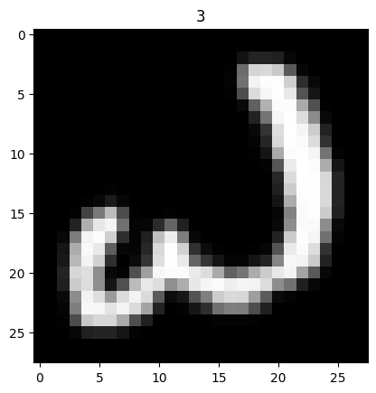

```python
show_example(2)
```

# preprocessing for cnn model

```python
from sklearn.base import BaseEstimator, TransformerMixin
from sklearn.pipeline import Pipeline
from sklearn.preprocessing import StandardScaler

class Reshaper(BaseEstimator, TransformerMixin):
    def fit(self, X, y=None):
        return self

    def transform(self, X):
        X_reshaped = X.reshape(-1, 28, 28, 1)
        return X_reshaped

# Define the pipeline
pipeline = Pipeline([
    ('scaler', StandardScaler()),  # Step 1: StandardScaler
    ('reshaper', Reshaper())  # Step 2: Custom Reshaper
])


# Fit and transform the training data

x_train_processed = pipeline.fit_transform(xtrain)
y_train_processed = np.eye(62)[ytrain.astype(int)]

x_test_processed = pipeline.transform(xtest)

y_test_processed = np.eye(62)[ytest.astype(int)]
```

```python
print('input shape',x_train_processed.shape)
print('output shape',ytrain.shape)
print('output shape',y_train_processed.shape)
```

```
input shape (697931, 28, 28, 1)
output shape (697931,)
output shape (697931, 62)
```

# Building the cnn model

```python
from keras.models import Sequential
from keras.layers import Conv2D,MaxPooling2D,Dense,Dropout,Flatten
```

```python
model = Sequential()

model.add(Conv2D(filters=32,kernel_size=(3,3),activation='relu',input_shape=(28,28,1)))
model.add(Dropout(0.25))
model.add(MaxPooling2D(pool_size=(2,2),strides=2))


model.add(Flatten())

model.add(Dense(128,activation='relu'))
model.add(Dropout(0.35))
model.add(Dense(62,activation='softmax'))
```

# Compiling the model

```python
model.compile(loss = 'categorical_crossentropy',optimizer='adam',metrics=['accuracy'])
```

# Model trainig

```python
history = model.fit(x_train_processed,y_train_processed,epochs = 6,batch_size=32,validation_data=(x_test_processed,y_test_processed))
```

```
21811/21811 ━━━━━━━━━━━━━━━━━━━━ 50s 2ms/step - accuracy: 0.8195 - loss: 0.5514 - val_accuracy: 0.8457 - val_loss: 0.6049
21811/21811 ━━━━━━━━━━━━━━━━━━━━ 48s 2ms/step - accuracy: 0.8184 - loss: 0.5578 - val_accuracy: 0.8437 - val_loss: 0.7087
21811/21811 ━━━━━━━━━━━━━━━━━━━━ 49s 2ms/step - accuracy: 0.8198 - loss: 0.5471 - val_accuracy: 0.8431 - val_loss: 0.9135
21811/21811 ━━━━━━━━━━━━━━━━━━━━ 48s 2ms/step - accuracy: 0.8193 - loss: 0.5554 - val_accuracy: 0.8441 - val_loss: 1.2964
21811/21811 ━━━━━━━━━━━━━━━━━━━━ 49s 2ms/step - accuracy: 0.8205 - loss: 0.5495 - val_accuracy: 0.8398 - val_loss: 0.7592
21811/21811 ━━━━━━━━━━━━━━━━━━━━ 49s 2ms/step - accuracy: 0.8208 - loss: 0.5502 - val_accuracy: 0.8385 - val_loss: 0.9565
```

### function to print compare predictions of our model with actual values

```python
def show_example_and_predicted_val(n,predicted_n) :

    true_val = alpha_num_to_char[ds_train.iloc[n,0]]  # the example's label
    predicted_val = alpha_num_to_char[predicted_n]  # the example's label

    plt.title("Actual val : "+ true_val+"\n Predicted :" + predicted_val)
    example = np.array(xtrain.iloc[n]) # extract the 28 *28 array that contains the pixels
    example_image = example.reshape(28 , 28 ) # rearrange the array to be a 28 by 28 matrix ,that represents that actual image
    plt.imshow(example_image , cmap ='gray')
    plt.axis('off')

    plt.show()
```

```
1/1 ━━━━━━━━━━━━━━━━━━━━ 0s 464ms/step
```

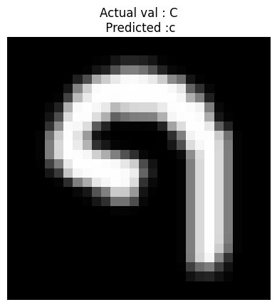

```python
# some example from the data set
x=4
example0=np.argmax(model.predict(x_train_processed[x].reshape(1,28,28,1)).flatten())
alpha_num_to_char[example0]
show_example_and_predicted_val(x,example0)
```

```python
# Now we are getting the model summary that tells us what were the different layers defined in the model &
# also we save the model using model.save() function.

model.summary()
```

```
Model: "sequential"
```

```
┏━━━━━━━━━━━━━━━━━━━━━━━━━━━━━━━━━┳━━━━━━━━━━━━━━━━━━━━━━━━┳━━━━━━━━━━━━━━━┓
┃ Layer (type)                    ┃ Output Shape           ┃       Param # ┃
┡━━━━━━━━━━━━━━━━━━━━━━━━━━━━━━━━━╇━━━━━━━━━━━━━━━━━━━━━━━━╇━━━━━━━━━━━━━━━┩
│ conv2d (Conv2D)                 │ (None, 26, 26, 32)     │           320 │
├─────────────────────────────────┼────────────────────────┼───────────────┤
│ dropout (Dropout)               │ (None, 26, 26, 32)     │             0 │
├─────────────────────────────────┼────────────────────────┼───────────────┤
│ max_pooling2d (MaxPooling2D)    │ (None, 13, 13, 32)     │             0 │
├─────────────────────────────────┼────────────────────────┼───────────────┤
│ flatten (Flatten)               │ (None, 5408)           │             0 │
├─────────────────────────────────┼────────────────────────┼───────────────┤
│ dense (Dense)                   │ (None, 128)            │       692,352 │
├─────────────────────────────────┼────────────────────────┼───────────────┤
│ dropout_1 (Dropout)             │ (None, 128)            │             0 │
├─────────────────────────────────┼────────────────────────┼───────────────┤
│ dense_1 (Dense)                 │ (None, 62)             │         7,998 │
└─────────────────────────────────┴────────────────────────┴───────────────┘
```

```
 Total params: 2,102,012 (8.02 MB)
```

```
 Trainable params: 700,670 (2.67 MB)
```

```
 Non-trainable params: 0 (0.00 B)
```

```
 Optimizer params: 1,401,342 (5.35 MB)
```

# MY DATA

## from this part of code I am importing self generated data

### The data was in the form of images that were converted into 2d arrays to fit the models input and output shape The code for preprocessing involved for the data is in the file named image_to_pixel2.ipynb

### This data was then imported to kaggle's environment and worked upon

```python
mydata = pd.read_csv('/kaggle/input/capital-samples/capital_samples.csv')
```

## how big is my data

```python
mydata.shape
```

```
(26, 785)
```

## sample of my data

```python
mydata.head()
```

|  | label | 1 | 2 | 3 | 4 | 5 | 6 | 7 | 8 | 9 | ... | 775 | 776 | 777 | 778 | 779 | 780 | 781 | 782 | 783 | 784 |
| --- | --- | --- | --- | --- | --- | --- | --- | --- | --- | --- | --- | --- | --- | --- | --- | --- | --- | --- | --- | --- | --- |
| 0 | 36 | 0.537255 | 0.537255 | 0.537255 | 0.549020 | 0.552941 | 0.552941 | 0.549020 | 0.560784 | 0.564706 | ... | 0.749020 | 0.737255 | 0.741176 | 0.737255 | 0.733333 | 0.733333 | 0.737255 | 0.729412 | 0.721569 | 0.713725 |
| 1 | 37 | 0.568627 | 0.564706 | 0.568627 | 0.568627 | 0.568627 | 0.564706 | 0.560784 | 0.572549 | 0.576471 | ... | 0.588235 | 0.592157 | 0.596078 | 0.596078 | 0.588235 | 0.592157 | 0.592157 | 0.596078 | 0.600000 | 0.600000 |
| 2 | 38 | 0.615686 | 0.619608 | 0.619608 | 0.623529 | 0.627451 | 0.635294 | 0.635294 | 0.635294 | 0.635294 | ... | 0.650980 | 0.650980 | 0.650980 | 0.647059 | 0.647059 | 0.650980 | 0.650980 | 0.654902 | 0.658824 | 0.658824 |
| 3 | 39 | 0.639216 | 0.639216 | 0.643137 | 0.635294 | 0.643137 | 0.643137 | 0.639216 | 0.639216 | 0.639216 | ... | 0.647059 | 0.643137 | 0.643137 | 0.643137 | 0.643137 | 0.643137 | 0.643137 | 0.643137 | 0.650980 | 0.654902 |
| 4 | 40 | 0.686275 | 0.682353 | 0.686275 | 0.686275 | 0.682353 | 0.682353 | 0.686275 | 0.686275 | 0.686275 | ... | 0.690196 | 0.686275 | 0.690196 | 0.686275 | 0.686275 | 0.682353 | 0.682353 | 0.686275 | 0.686275 | 0.686275 |

5 rows × 785 columns

# dataset description :

#### the dataset contains the images of all the english alphabets handwritten by me, therefore the size of the data is 26. These images are then converted to 2d arrays to store into a csv file of length 785 to match the previously fitted model.

```python
mydata_xtrain = mydata.drop(['label'],axis =1)
mydata_ytrain = mydata['label']

mydata_xtest = mydata.drop(['label'],axis =1)
mydata_ytest = mydata['label']
```

# preprocessing the splitted data

```python
class Reshaper(BaseEstimator, TransformerMixin):
    def fit(self, X, y=None):
        return self

    def transform(self, X):
        X_reshaped = X.reshape(-1, 28, 28, 1)
        return X_reshaped

# Define the pipeline
pipeline = Pipeline([
    ('scaler', StandardScaler()),  # Step 1: StandardScaler
    ('reshaper', Reshaper())  # Step 2: Custom Reshaper
])


# Fit and transform the training data

mydata_xtrain_processed = pipeline.fit_transform(mydata_xtrain)
mydata_ytrain_processed = np.eye(62)[mydata_ytrain.astype(int)]

mydata_xtest_processed = pipeline.fit_transform(mydata_xtest)
mydata_ytest_processed = np.eye(62)[mydata_ytest.astype(int)]
```

```python
print('input shape',mydata_xtrain_processed.shape)
print('output shape',mydata_ytrain.shape)
print('output shape',mydata_ytrain_processed.shape)
```

```
input shape (26, 28, 28, 1)
output shape (26,)
output shape (26, 62)
```

# model training

### we are using the previously trained model on the emnist dataset to be trained on my data as well

```python
history2 = model.fit(mydata_xtrain_processed,mydata_ytrain_processed,epochs = 6,batch_size=32,validation_data=(mydata_xtest_processed,mydata_ytest_processed))
```

```
1/1 ━━━━━━━━━━━━━━━━━━━━ 0s 82ms/step - accuracy: 0.7308 - loss: 0.7559 - val_accuracy: 0.9615 - val_loss: 0.1352
1/1 ━━━━━━━━━━━━━━━━━━━━ 0s 41ms/step - accuracy: 0.8077 - loss: 0.6499 - val_accuracy: 0.9615 - val_loss: 0.1305
1/1 ━━━━━━━━━━━━━━━━━━━━ 0s 40ms/step - accuracy: 0.8462 - loss: 0.7886 - val_accuracy: 0.9615 - val_loss: 0.1266
1/1 ━━━━━━━━━━━━━━━━━━━━ 0s 41ms/step - accuracy: 0.8462 - loss: 0.4825 - val_accuracy: 0.9615 - val_loss: 0.1233
1/1 ━━━━━━━━━━━━━━━━━━━━ 0s 39ms/step - accuracy: 0.8462 - loss: 0.4966 - val_accuracy: 0.9615 - val_loss: 0.1196
1/1 ━━━━━━━━━━━━━━━━━━━━ 0s 40ms/step - accuracy: 0.9615 - loss: 0.2344 - val_accuracy: 0.9615 - val_loss: 0.1161
```

```python
# Evaluate the model
test_loss, test_acc = model.evaluate(mydata_xtest_processed, mydata_ytest_processed)
print('Test loss:', test_loss)
print('Test accuracy:', test_acc)
```

```
1/1 ━━━━━━━━━━━━━━━━━━━━ 0s 23ms/step - accuracy: 0.9615 - loss: 0.1161
Test loss: 0.11607286334037781
Test accuracy: 0.9615384340286255
```

# data augumentation

### since we have very less data for training our model we will generate more augumented images using our dataset and train our model on them as well so that it performs good on the test results as well

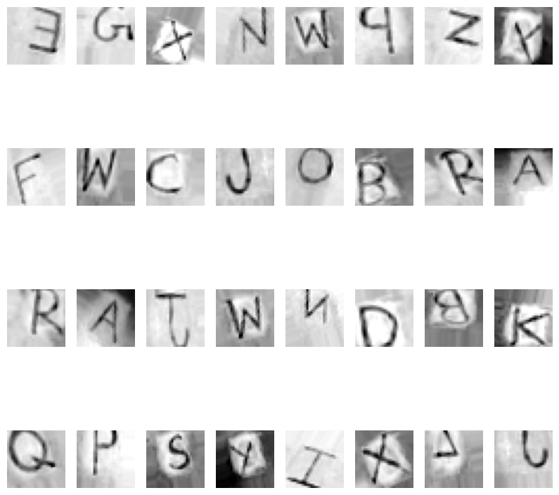

```python
from tensorflow.keras.preprocessing.image import ImageDataGenerator

# Define data augmentation parameters
datagen = ImageDataGenerator(
    rotation_range=25,           # Rotate images randomly by up to 10 degrees
    width_shift_range=0.2,       # Shift images horizontally by up to 10% of the width
    height_shift_range=0.2,      # Shift images vertically by up to 10% of the height
    shear_range=0.2,             # Shear transformation (skewing) with a maximum shear intensity of 20%
    zoom_range=0.2,              # Zoom in/out on images by up to 20%
    horizontal_flip=True,        # Flip images horizontally (left/right)
    vertical_flip=False,         # Don't flip images vertically (up/down)
    brightness_range=[0.8, 1.2], # Randomly adjust brightness between 0.8 and 1.2
    channel_shift_range=0.2,     # Randomly shift color channels by up to 20%
    fill_mode='nearest'          # Fill in missing pixels after rotation or shift
)

# Load and preprocess your dataset (x_train and y_train)

# Fit the ImageDataGenerator to your training data
datagen.fit(mydata_xtrain_processed)

# Visualize some augmented images
import matplotlib.pyplot as plt

# Visualize some augmented images
plt.figure(figsize=(10, 10))
num_batches = 4  # Generate 3 batches of augmented data
for batch_index, (X_batch, y_batch) in enumerate(datagen.flow(mydata_xtrain_processed, mydata_ytrain_processed, batch_size=26)):
    for i in range(0, 8):  # Display 8 images from each batch
        plt.subplot(num_batches, 8, batch_index * 8 + i + 1)
        plt.imshow(X_batch[i].reshape(28, 28), cmap=plt.get_cmap('gray'))
        plt.axis('off')
    if batch_index == num_batches - 1:
        break  # Stop after generating the desired number of batches
plt.show()
```

```python
len(X_batch)
```

```
26
```

## model training on the augumented images

```python
history3 = model.fit(X_batch,y_batch,batch_size=32,steps_per_epoch=int(len(X_batch) / 32),  epochs=4)
```

```
1/1 ━━━━━━━━━━━━━━━━━━━━ 0s 24ms/step - accuracy: 0.9615 - loss: 0.1888
1/1 ━━━━━━━━━━━━━━━━━━━━ 0s 23ms/step - accuracy: 0.9231 - loss: 0.1608
1/1 ━━━━━━━━━━━━━━━━━━━━ 0s 31ms/step - accuracy: 0.9231 - loss: 0.3299
1/1 ━━━━━━━━━━━━━━━━━━━━ 0s 31ms/step - accuracy: 0.9615 - loss: 0.1271
```

# testing our model

### here we are testing our models results using the images from our dataset to predict their result

```
1/1 ━━━━━━━━━━━━━━━━━━━━ 0s 17ms/step
```

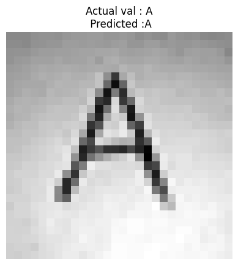

```
1/1 ━━━━━━━━━━━━━━━━━━━━ 0s 17ms/step
```

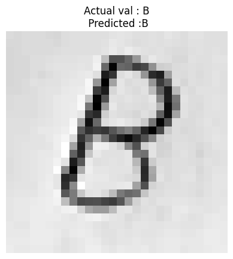

```
1/1 ━━━━━━━━━━━━━━━━━━━━ 0s 18ms/step
```

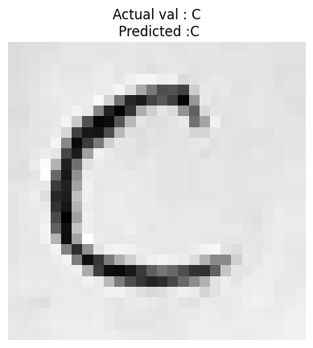

```
1/1 ━━━━━━━━━━━━━━━━━━━━ 0s 17ms/step
```

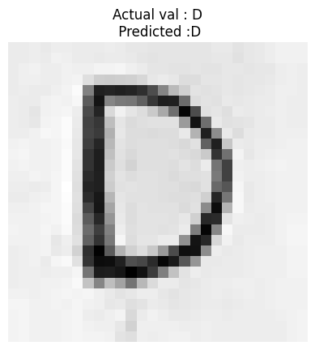

```
1/1 ━━━━━━━━━━━━━━━━━━━━ 0s 17ms/step
```

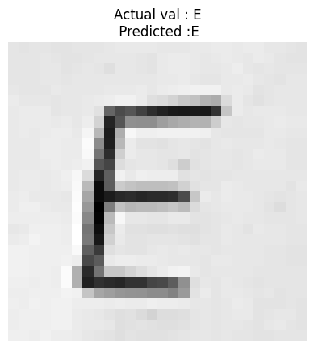

```
1/1 ━━━━━━━━━━━━━━━━━━━━ 0s 17ms/step
```

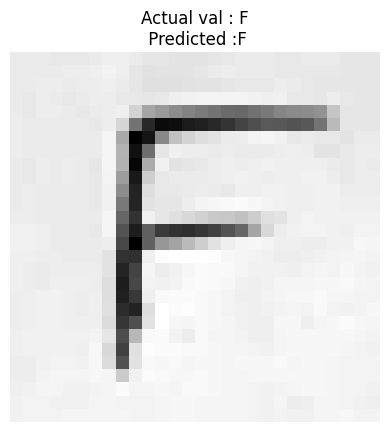

```
1/1 ━━━━━━━━━━━━━━━━━━━━ 0s 17ms/step
```

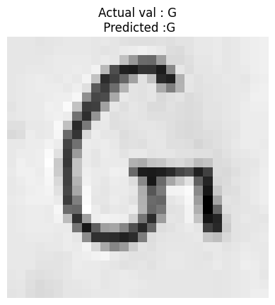

```
1/1 ━━━━━━━━━━━━━━━━━━━━ 0s 17ms/step
```

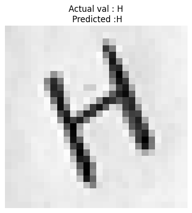

```
1/1 ━━━━━━━━━━━━━━━━━━━━ 0s 17ms/step
```

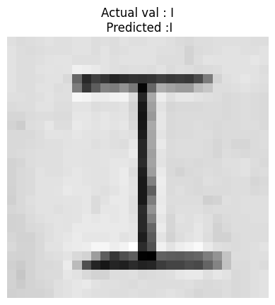

```
1/1 ━━━━━━━━━━━━━━━━━━━━ 0s 17ms/step
```

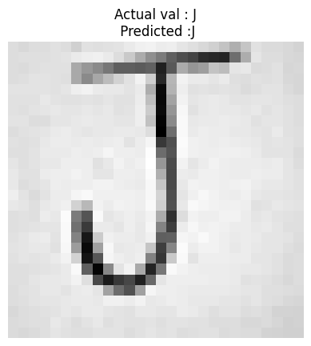

```
1/1 ━━━━━━━━━━━━━━━━━━━━ 0s 17ms/step
```

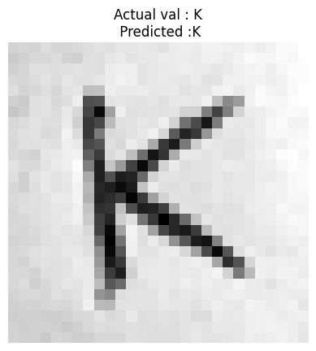

```
1/1 ━━━━━━━━━━━━━━━━━━━━ 0s 17ms/step
```

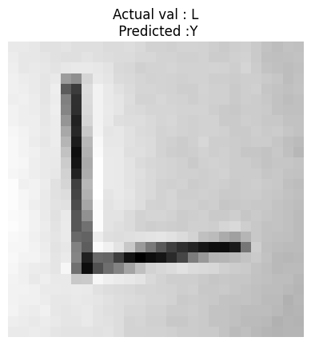

```
1/1 ━━━━━━━━━━━━━━━━━━━━ 0s 17ms/step
```

[14 more figures not shown]

```python
def show_example_and_predicted_val_mydata(n,predicted_n) :

    true_val = alpha_num_to_char[mydata.iloc[n,0]]  # the example's label
    predicted_val = alpha_num_to_char[predicted_n]  # the example's label

    plt.title("Actual val : "+ true_val+"\n Predicted :" + predicted_val)
    example = np.array(mydata_xtrain.iloc[n]) # extract the 28 *28 array that contains the pixels
    example_image = example.reshape(28 , 28 ) # rearrange the array to be a 28 by 28 matrix ,that represents that actual image
    plt.imshow(example_image , cmap ='gray')
    plt.axis('off')

    plt.show()

# some example from the data set
for i in range(0,26):
    example0=np.argmax(model.predict(mydata_xtrain_processed[i].reshape(1,28,28,1)).flatten())
    alpha_num_to_char[example0]
    show_example_and_predicted_val_mydata(i,example0)
```

```python
model.save(f'best_till_now.h5')
```

# CONCLUSION

## Thus the model detects the handwritten capital alphabetical letters and predict it using tensorflow model

## This model can be trained and improved further on bigger words to get better and versatile results.